# Regression and Other Stories: Bayesian $R^2$

Andrew Gelman, Jennifer Hill, Aki Vehtari

2020-08-22

Bayesian $R^2$. See Chapter 11 in Regression and Other Stories.

See also - Andrew Gelman, Ben Goodrich, Jonah Gabry, and Aki Vehtari (2018). R-squared for Bayesian regression models. The American Statistician, 73:307-209 [doi:10.1080/00031305.2018.1549100](https://doi.org/10.1080/00031305.2018.1549100).

## Introduction

Gelman, Goodrich, Gabry, and Vehtari (2018) define Bayesian $R^2$ as
$$R^2 = \frac{\mathrm{Var}_{\mu}}{\mathrm{Var}_{\mu}+\mathrm{Var}_\mathrm{res}},$$
where $\mathrm{Var}_{\mu}$ is variance of modelled predictive means, and $\mathrm{Var}_\mathrm{res}$ is the modelled residual variance. Specifically both of these are computed only using posterior quantities from the fitted model. The model based $R^2$ uses draws from the model and residual variances. For linear regression $\mu_n=X_n\beta$ we define
$$\mathrm{Var}_\mathrm{\mu}^s = V_{n=1}^N \mu_n^s\\
\mathrm{Var}_\mathrm{res}^s = (\sigma^2)^s,$$
and for logistic regression, following Tjur (2009), we define $\mu_n=\pi_n$ and
$$\mathrm{Var}_\mathrm{\mu}^s = V_{n=1}^N \mu_n^s\\
\mathrm{Var}_\mathrm{res}^s = \frac{1}{N}\sum_{n=1}^N (\pi_n^s(1-\pi_n^s)),$$
where $\pi_n^s$ are predicted probabilities.

#### Load packages

```r
library("rprojroot")
root<-has_file(".ROS-Examples-root")$make_fix_file()
library("rstanarm")
library("ggplot2")
library("bayesplot")
theme_set(bayesplot::theme_default(base_family = "sans"))
library("foreign")
# for reproducability
SEED <- 1800
set.seed(SEED)
```

#### Function for Bayesian R-squared for stan_glm models.

Bayes-R2 function using modelled (approximate) residual variance

```r
bayes_R2 <- function(fit) {
  mupred <- rstanarm::posterior_linpred(fit, transform = TRUE)
  var_mupred <- apply(mupred, 1, var)
  if (family(fit)$family == "binomial" && NCOL(y) == 1) {
      sigma2 <- apply(mupred*(1-mupred), 1, mean)
  } else {
      sigma2 <- as.matrix(fit, pars = c("sigma"))^2
  }
  var_mupred / (var_mupred + sigma2)
}
```

## Toy data with n=5

```r
x <- 1:5 - 3
y <- c(1.7, 2.6, 2.5, 4.4, 3.8) - 3
xy <- data.frame(x,y)
```

#### Lsq fit

```r
fit <- lm(y ~ x, data = xy)
ols_coef <- coef(fit)
yhat <- ols_coef[1] + ols_coef[2] * x
r <- y - yhat
rsq_1 <- var(yhat)/(var(y))
rsq_2 <- var(yhat)/(var(yhat) + var(r))
round(c(rsq_1, rsq_2), 3)
```

```
[1] 0.766 0.766
```

#### Bayes fit

```r
fit_bayes <- stan_glm(y ~ x, data = xy,
  prior_intercept = normal(0, 0.2, autoscale = FALSE),
  prior = normal(1, 0.2, autoscale = FALSE),
  prior_aux = NULL,
  seed = SEED, refresh = 0
)
posterior <- as.matrix(fit_bayes, pars = c("(Intercept)", "x"))
post_means <- colMeans(posterior)
```

#### Median Bayesian R^2

```r
round(median(bayesR2<-bayes_R2(fit_bayes)), 2)
```

```
[1] 0.74
```

#### Figures

The first section of code below creates plots using base R graphics.  
Below that there is code to produce the plots using ggplot2.

```r
# take a sample of 20 posterior draws
keep <- sample(nrow(posterior), 20)
samp_20_draws <- posterior[keep, ]
```

#### Base graphics version

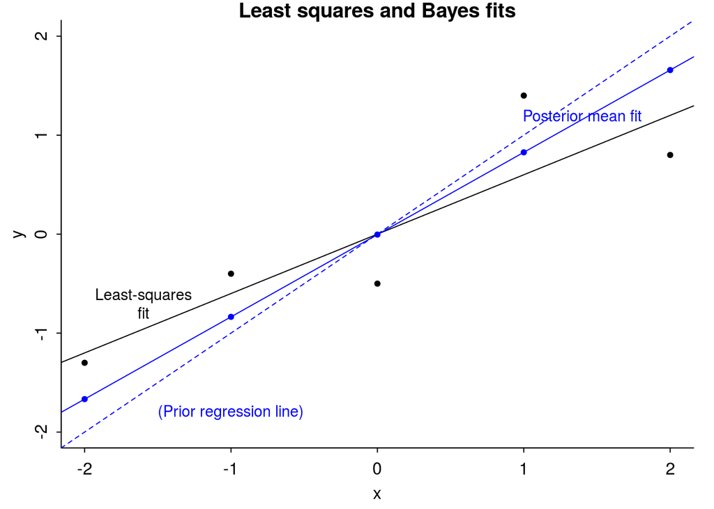

```r
par(mar=c(3,3,1,1), mgp=c(1.7,.5,0), tck=-.01)
plot(
  x, y,
  ylim = range(x),
  xlab = "x",
  ylab = "y",
  main = "Least squares and Bayes fits",
  bty = "l",
  pch = 20
)
abline(coef(fit)[1], coef(fit)[2], col = "black")
text(-1.6,-.7, "Least-squares\nfit", cex = .9)
abline(0, 1, col = "blue", lty = 2)
text(-1, -1.8, "(Prior regression line)", col = "blue", cex = .9)
abline(coef(fit_bayes)[1], coef(fit_bayes)[2], col = "blue")
text(1.4, 1.2, "Posterior mean fit", col = "blue", cex = .9)
points(
  x,
  coef(fit_bayes)[1] + coef(fit_bayes)[2] * x,
  pch = 20,
  col = "blue"
)
```

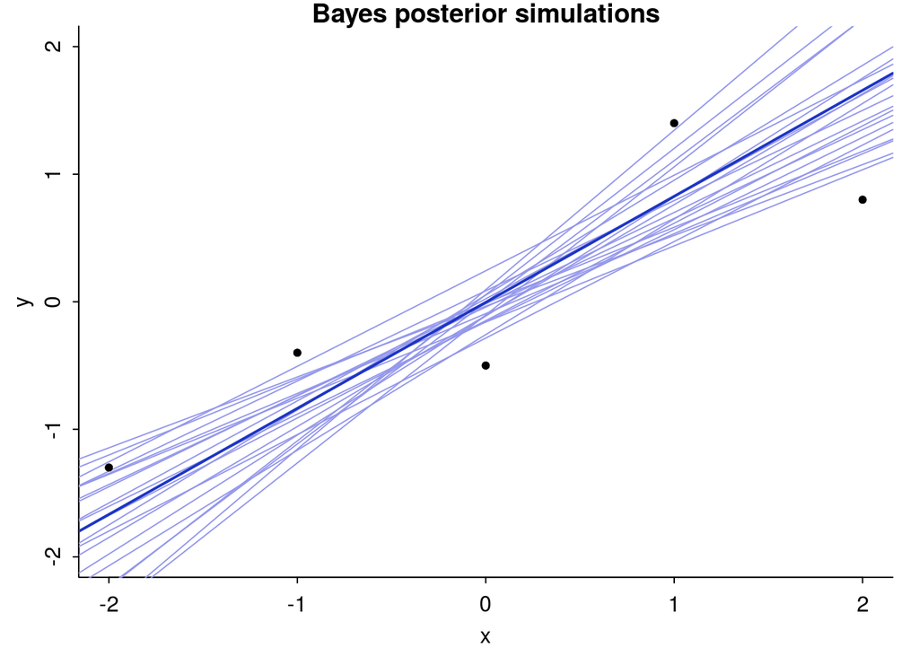

```r
par(mar=c(3,3,1,1), mgp=c(1.7,.5,0), tck=-.01)
plot(
  x, y,
  ylim = range(x),
  xlab = "x",
  ylab = "y",
  bty = "l",
  pch = 20,
  main = "Bayes posterior simulations"
)
for (s in 1:nrow(samp_20_draws)) {
  abline(samp_20_draws[s, 1], samp_20_draws[s, 2], col = "#9497eb")
}
abline(
  coef(fit_bayes)[1],
  coef(fit_bayes)[2],
  col = "#1c35c4",
  lwd = 2
)
points(x, y, pch = 20, col = "black")
```

#### ggplot version

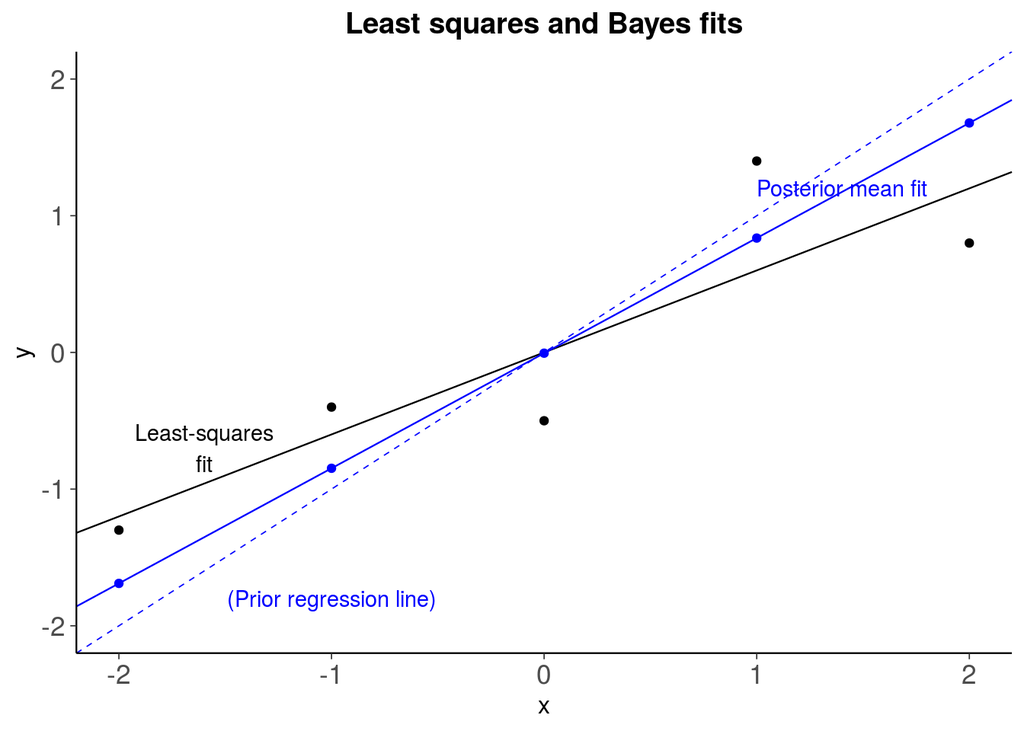

```r
theme_update(
  plot.title = element_text(face = "bold", hjust = 0.5),
  axis.text = element_text(size = rel(1.1))
)
fig_1a <-
  ggplot(xy, aes(x, y)) +
  geom_point() +
  geom_abline( # ols regression line
    intercept = ols_coef[1],
    slope = ols_coef[2],
    size = 0.4
  ) +
  geom_abline( # prior regression line
    intercept = 0,
    slope = 1,
    color = "blue",
    linetype = 2,
    size = 0.3
  ) +
  geom_abline( # posterior mean regression line
    intercept = post_means[1],
    slope = post_means[2],
    color = "blue",
    size = 0.4
  ) +
  geom_point(
    aes(y = post_means[1] + post_means[2] * x),
    color = "blue"
  ) +
  annotate(
    geom = "text",
    x = c(-1.6, -1, 1.4),
    y = c(-0.7, -1.8, 1.2),
    label = c(
      "Least-squares\nfit",
      "(Prior regression line)",
      "Posterior mean fit"
    ),
    color = c("black", "blue", "blue"),
    size = 3.8
  ) +
  ylim(range(x)) +
  ggtitle("Least squares and Bayes fits")
plot(fig_1a)
```

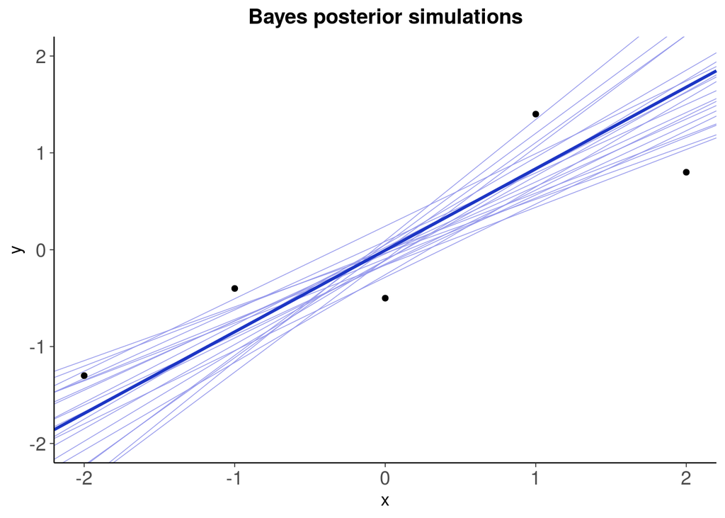

```r
fig_1b <-
  ggplot(xy, aes(x, y)) +
  geom_abline( # 20 posterior draws of the regression line
    intercept = samp_20_draws[, 1],
    slope = samp_20_draws[, 2],
    color = "#9497eb",
    size = 0.25
  ) +
  geom_abline( # posterior mean regression line
    intercept = post_means[1],
    slope = post_means[2],
    color = "#1c35c4",
    size = 1
  ) +
  geom_point() +
  ylim(range(x)) +
  ggtitle("Bayes posterior simulations")
plot(fig_1b)
```

#### Bayesian R^2 Posterior and median

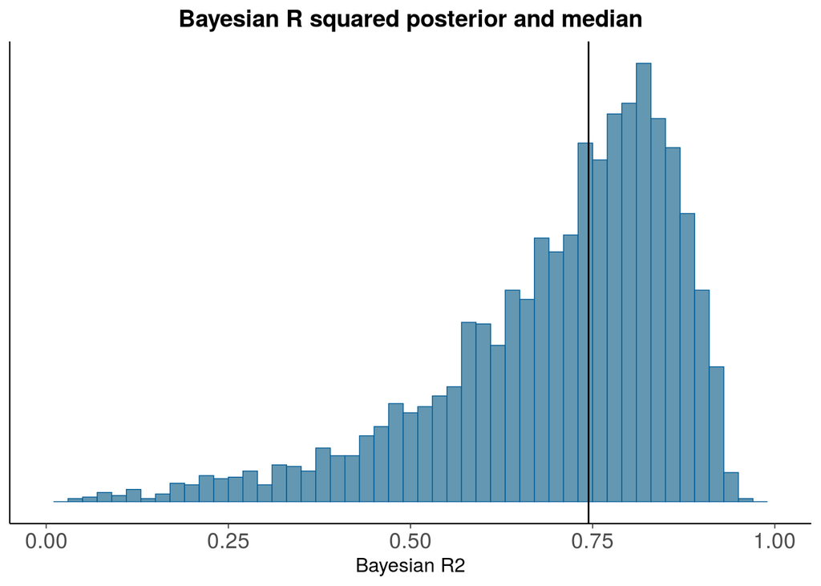

```r
mcmc_hist(data.frame(bayesR2), binwidth=0.02) + xlim(c(0,1)) +
    scale_y_continuous(breaks=NULL) +
    xlab('Bayesian R2') +
    geom_vline(xintercept=median(bayesR2)) +
    ggtitle('Bayesian R squared posterior and median')
```

## Toy logistic regression example, n=20

```r
set.seed(20)
y<-rbinom(n=20,size=1,prob=(1:20-0.5)/20)
data <- data.frame(rvote=y, income=1:20)
fit_logit <- stan_glm(rvote ~ income, family=binomial(link="logit"), data=data,
                      refresh=0)
```

#### Median Bayesian R^2

```r
round(median(bayesR2<-bayes_R2(fit_logit)), 2)
```

```
[1] 0.39
```

#### Plot posterior of Bayesian R^2

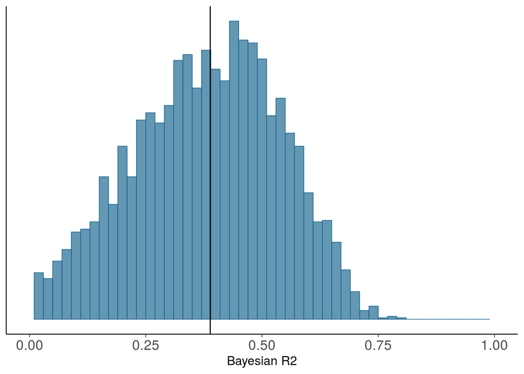

```r
pxl<-xlim(0,1)
mcmc_hist(data.frame(bayesR2), binwidth=0.02) + pxl +
    scale_y_continuous(breaks=NULL) +
    xlab('Bayesian R2') +
    geom_vline(xintercept=median(bayesR2))
```

## Mesquite - linear regression

Predicting the yields of mesquite bushes, n=46

#### Load data

```r
mesquite <- read.table(root("Mesquite/data","mesquite.dat"), header=TRUE)
mesquite$canopy_volume <- mesquite$diam1 * mesquite$diam2 * mesquite$canopy_height
mesquite$canopy_area <- mesquite$diam1 * mesquite$diam2
mesquite$canopy_shape <- mesquite$diam1 / mesquite$diam2
(n <- nrow(mesquite))
```

```
[1] 46
```

#### Predict log weight model with log canopy volume, log canopy shape, and group

```r
fit_5 <- stan_glm(log(weight) ~ log(canopy_volume) + log(canopy_shape) +
    group, data=mesquite, refresh=0)
```

#### Median Bayesian R2

```r
round(median(bayesR2<-bayes_R2(fit_5)), 2)
```

```
[1] 0.87
```

#### Plot posterior of Bayesian R2

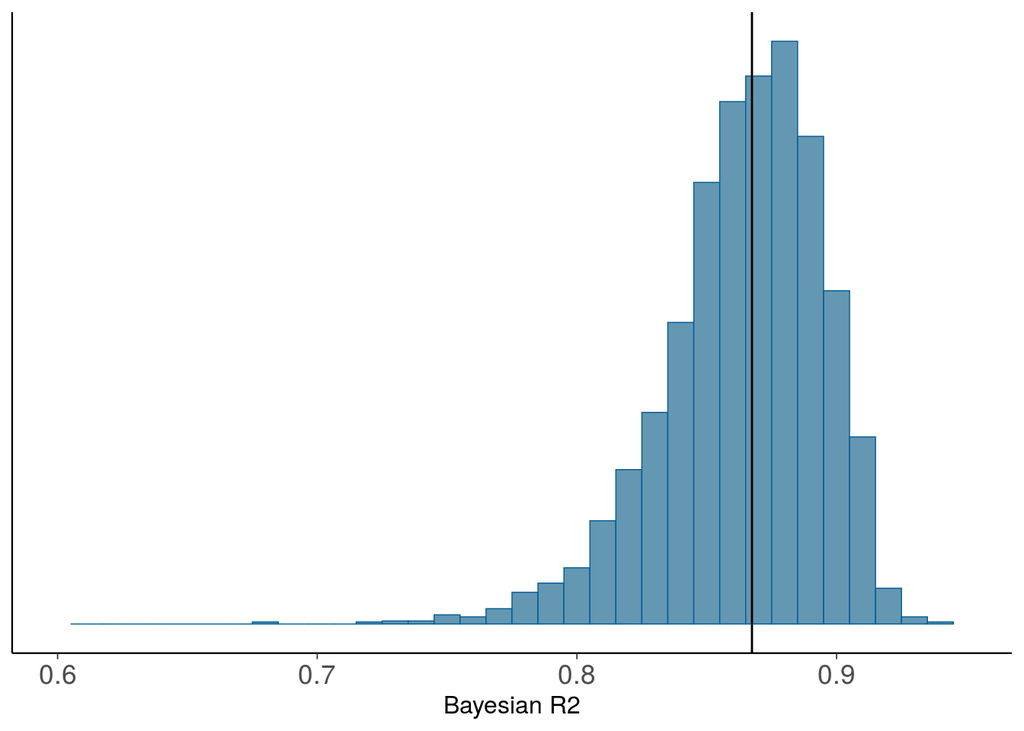

```r
pxl<-xlim(0.6, 0.95)
mcmc_hist(data.frame(bayesR2), binwidth=0.01) + pxl +
    scale_y_continuous(breaks=NULL) +
    xlab('Bayesian R2') +
    geom_vline(xintercept=median(bayesR2))
```

## LowBwt -- logistic regression

Predict low birth weight, n=189, from Hosmer et al (2000). This data was also used by Tjur (2009)

#### Load data

```r
lowbwt <- read.table(root("LowBwt/data","lowbwt.dat"), header=TRUE)
(n <- nrow(lowbwt))
```

```
[1] 189
```

```r
head(lowbwt)
```

```
  ID low age lwt race smoke ptl ht ui ftv  bwt
1 85   0  19 182    2     0   0  0  1   0 2523
2 86   0  33 155    3     0   0  0  0   3 2551
3 87   0  20 105    1     1   0  0  0   1 2557
4 88   0  21 108    1     1   0  0  1   2 2594
5 89   0  18 107    1     1   0  0  1   0 2600
6 91   0  21 124    3     0   0  0  0   0 2622
```

#### Predict low birth weight

```r
fit_1 <- stan_glm(low ~ age + lwt + factor(race) + smoke,
                family=binomial(link="logit"), data=lowbwt, refresh=0)
```

#### Median Bayesian R2

```r
round(median(bayesR2<-bayes_R2(fit_1)), 2)
```

```
[1] 0.12
```

#### Plot posterior of Bayesian R2

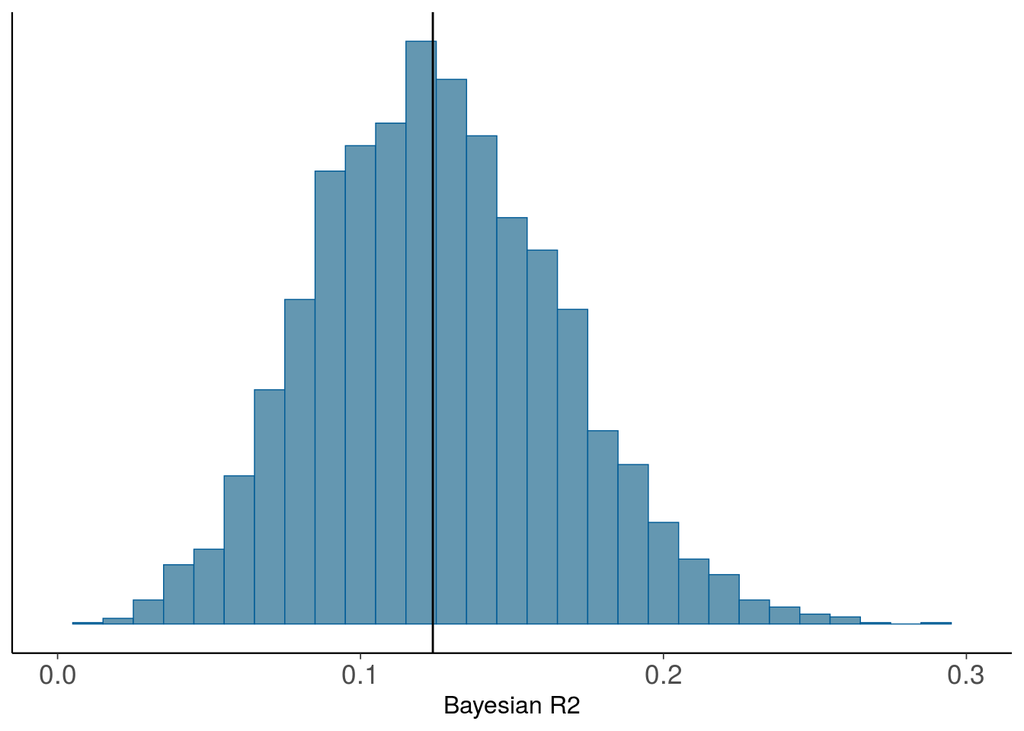

```r
pxl<-xlim(0, 0.3)
mcmc_hist(data.frame(bayesR2), binwidth=0.01) + pxl +
    scale_y_continuous(breaks=NULL) +
    xlab('Bayesian R2') +
    geom_vline(xintercept=median(bayesR2))
```

## LowBwt -- linear regression

Predict birth weight, n=189, from Hosmer et al. (2000). Tjur (2009) used logistic regression for dichotomized birth weight. Below we use the continuos valued birth weight.

#### Predict birth weight

```r
fit_2 <- stan_glm(bwt ~ age + lwt + factor(race) + smoke, data=lowbwt, refresh=0)
```

#### Median Bayesian R2

```r
round(median(bayesR2<-bayes_R2(fit_2)), 2)
```

```
[1] 0.16
```

#### Plot posterior of Bayesian R2

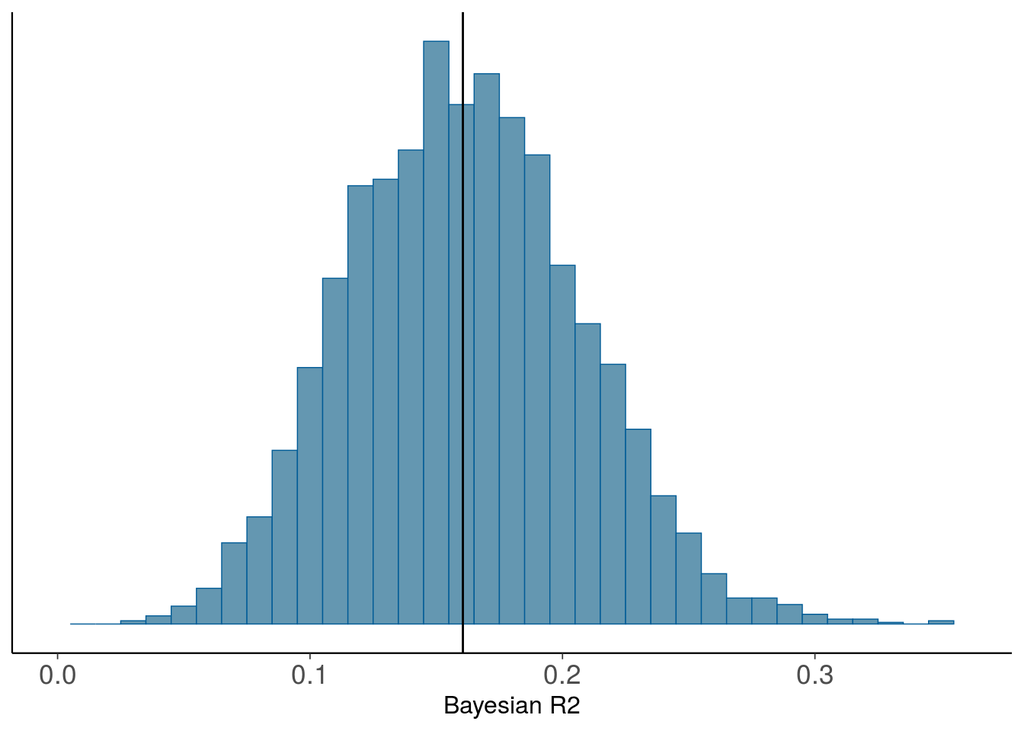

```r
pxl<-xlim(0, 0.36)
mcmc_hist(data.frame(bayesR2), binwidth=0.01) + pxl +
    scale_y_continuous(breaks=NULL) +
    xlab('Bayesian R2') +
    geom_vline(xintercept=median(bayesR2))
```

## KidIQ - linear regression

Children's test scores data, n=434

#### Load children's test scores data

```r
kidiq <- read.csv(root("KidIQ/data","kidiq.csv"))
(n <- nrow(kidiq))
```

```
[1] 434
```

```r
head(kidiq)
```

```
  kid_score mom_hs    mom_iq mom_work mom_age
1        65      1 121.11753        4      27
2        98      1  89.36188        4      25
3        85      1 115.44316        4      27
4        83      1  99.44964        3      25
5       115      1  92.74571        4      27
6        98      0 107.90184        1      18
```

#### Predict test score

```r
fit_3 <- stan_glm(kid_score ~ mom_hs + mom_iq, data=kidiq,
                  seed=SEED, refresh=0)
```

#### Median Bayesian R2

```r
round(median(bayesR2<-bayes_R2(fit_3)), 2)
```

```
[1] 0.21
```

#### Plot posterior of Bayesian R2

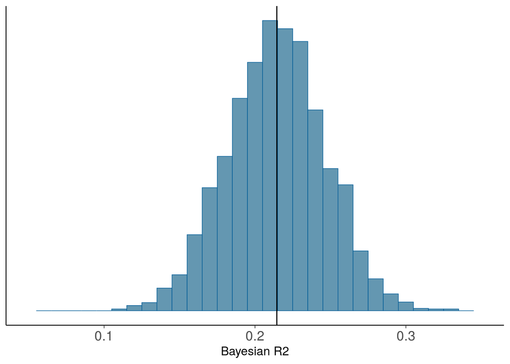

```r
pxl<-xlim(0.05, 0.35)
mcmc_hist(data.frame(bayesR2), binwidth=0.01) + pxl +
    scale_y_continuous(breaks=NULL) +
    xlab('Bayesian R2') +
    geom_vline(xintercept=median(bayesR2))
```

#### Add five pure noise predictors to the data

```r
set.seed(1507)
n <- nrow(kidiq)
kidiqr <- kidiq
kidiqr$noise <- array(rnorm(5*n), c(n,5))
```

#### Linear regression with additional noise predictors

```r
fit_3n <- stan_glm(kid_score ~ mom_hs + mom_iq + noise, data=kidiqr,
                   seed=SEED, refresh=0)
print(fit_3n)
```

```
stan_glm
 family:       gaussian [identity]
 formula:      kid_score ~ mom_hs + mom_iq + noise
 observations: 434
 predictors:   8
------
            Median MAD_SD
(Intercept) 25.7    5.8
mom_hs       6.0    2.3
mom_iq       0.6    0.1
noise1      -0.1    0.8
noise2      -1.3    0.9
noise3       0.0    1.0
noise4       0.2    0.9
noise5      -0.5    0.9

Auxiliary parameter(s):
      Median MAD_SD
sigma 18.2    0.6

------
* For help interpreting the printed output see ?print.stanreg
* For info on the priors used see ?prior_summary.stanreg
```

#### Median Bayesian R2

```r
round(median(bayesR2n<-bayes_R2(fit_3n)), 2)
```

```
[1] 0.22
```

Median Bayesian R2 is higher with additional noise predictors, but the distribution of Bayesian R2 reveals that the increase is not practically relevant.

#### Plot posterior of Bayesian R2

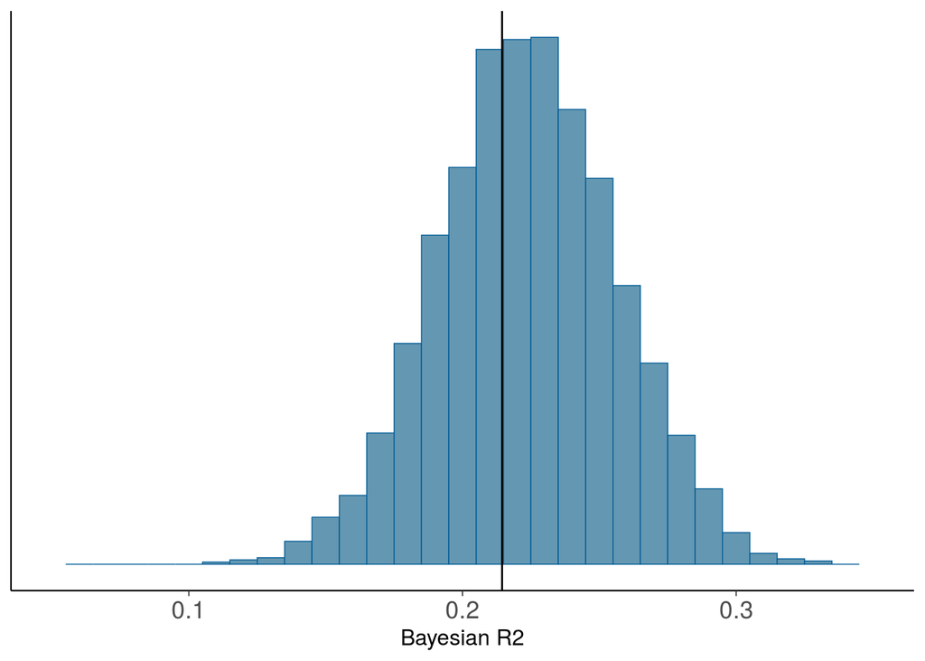

```r
pxl<-xlim(0.05, 0.35)
mcmc_hist(data.frame(bayesR2n), binwidth=0.01) + pxl +
    scale_y_continuous(breaks=NULL) +
    xlab('Bayesian R2') +
    geom_vline(xintercept=median(bayesR2))
```

## Earnings - logistic and linear regression

Predict respondents' yearly earnings using survey data from 1990.  
logistic regression n=1374, linear regression n=1187

#### Load data

```r
earnings <- read.csv(root("Earnings/data","earnings.csv"))
(n <- nrow(earnings))
```

```
[1] 1816
```

```r
head(earnings)
```

```
  height weight male  earn earnk ethnicity education mother_education
1     74    210    1 50000    50     White        16               16
2     66    125    0 60000    60     White        16               16
3     64    126    0 30000    30     White        16               16
4     65    200    0 25000    25     White        17               17
5     63    110    0 50000    50     Other        16               16
6     68    165    0 62000    62     Black        18               18
  father_education walk exercise smokenow tense angry age
1               16    3        3        2     0     0  45
2               16    6        5        1     0     0  58
3               16    8        1        2     1     1  29
4               NA    8        1        2     0     0  57
5               16    5        6        2     0     0  91
6               18    1        1        2     2     2  54
```

#### Bayesian logistic regression on non-zero earnings

Predict using height and sex

```r
fit_1a <- stan_glm((earn>0) ~ height + male,
                   family = binomial(link = "logit"),
                   data = earnings, refresh=0)
```

#### Median Bayesian R2

```r
round(median(bayesR2<-bayes_R2(fit_1a)), 3)
```

```
[1] 0.046
```

#### Plot posterior of Bayesian R2

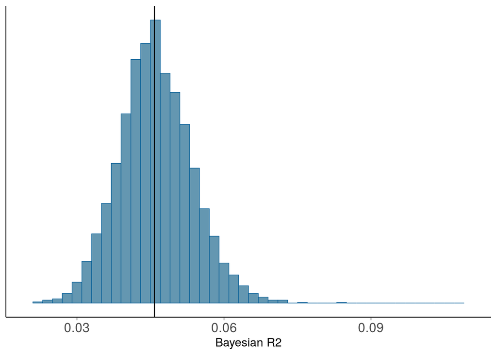

```r
pxl<-xlim(0.02, 0.11)
mcmc_hist(data.frame(bayesR2), binwidth=0.002) + pxl +
    scale_y_continuous(breaks=NULL) +
    xlab('Bayesian R2') +
    geom_vline(xintercept=median(bayesR2))
```

#### Bayesian probit regression on non-zero earnings

```r
fit_1p <- stan_glm((earn>0) ~ height + male,
                   family = binomial(link = "probit"),
                   data = earnings, refresh=0)
```

#### Median Bayesian R2

```r
round(median(bayesR2), 3)
```

```
[1] 0.046
```

```r
round(median(bayesR2p<-bayes_R2(fit_1p)), 3)
```

```
[1] 0.046
```

#### Compare logistic and probit models using new Bayesian R2

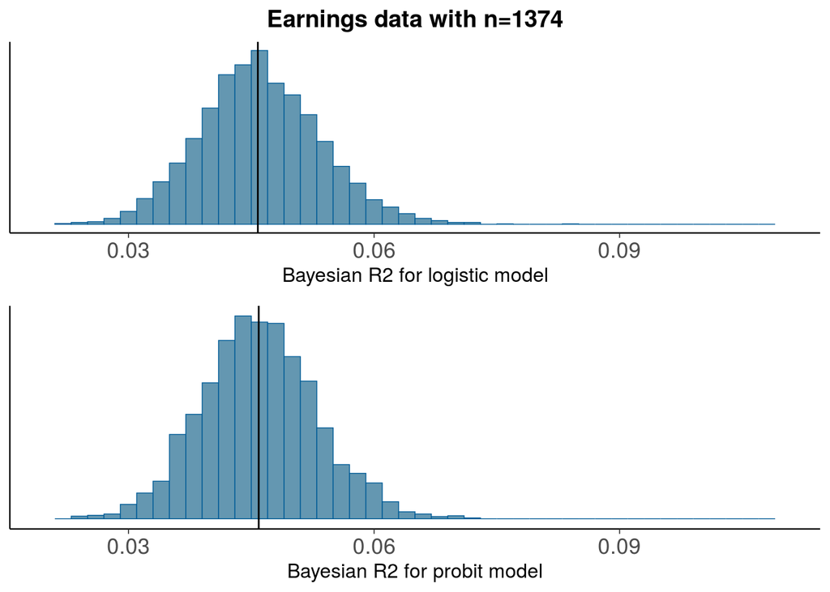

```r
pxl<-xlim(0.02, 0.11)
p1<-mcmc_hist(data.frame(bayesR2), binwidth=0.002) + pxl +
    scale_y_continuous(breaks=NULL) +
    ggtitle('Earnings data with n=1374') +
    xlab('Bayesian R2 for logistic model') +
    geom_vline(xintercept=median(bayesR2))
p2<-mcmc_hist(data.frame(bayesR2p), binwidth=0.002) + pxl +
    scale_y_continuous(breaks=NULL) +
    xlab('Bayesian R2 for probit model') +
    geom_vline(xintercept=median(bayesR2p))
bayesplot_grid(p1,p2)
```

There is no practical difference in predictive performance between logit and probit.

#### Bayesian model on positive earnings on log scale

```r
fit_1b <- stan_glm(log(earn) ~ height + male, data = earnings, subset=earn>0,
                   refresh=0)
```

#### Median Bayesian R2

```r
round(median(bayesR2<-bayes_R2(fit_1b)), 3)
```

```
[1] 0.08
```

#### Plot posterior of Bayesian R2

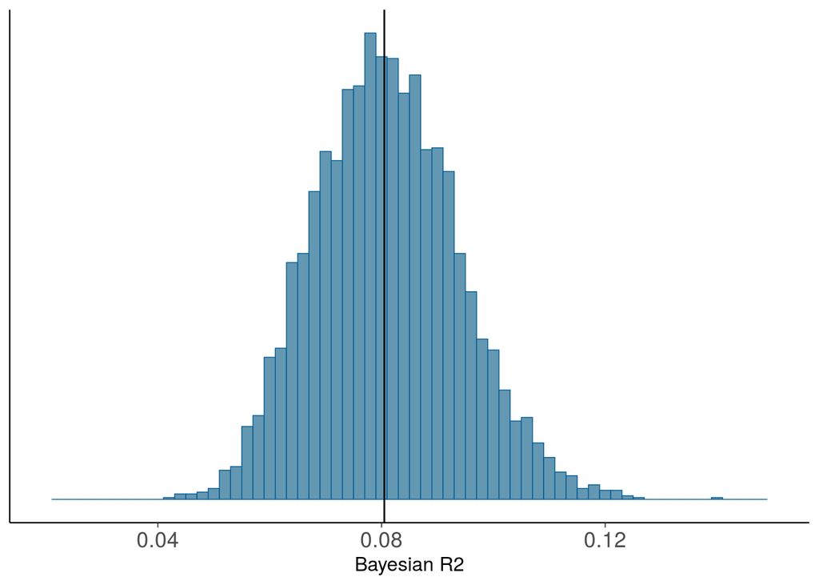

```r
pxl<-xlim(0.02, 0.15)
mcmc_hist(data.frame(bayesR2), binwidth=0.002) + pxl +
    scale_y_continuous(breaks=NULL) +
    xlab('Bayesian R2') +
    geom_vline(xintercept=median(bayesR2))
```